# Resultados StrainR2

# Resumen global de la referencia

La Fase 1 de `PreProcessR` terminó correctamente y produjo una base de referencia para las 26 cepas. El resumen calculado directamente desde `KmerContent.report` es:

| Métrica | Valor |
| --- | --- |
| records | 3.724000e+03 |
| excluded | 1.800000e+01 |
| useful | 3.706000e+03 |
| Nunique_total | 2.572418e+08 |
| mean_percent_unique | 9.840200e+01 |

En total se registraron 3.724 subcontigs: 3.706 fueron útiles y 18 fueron excluidos. La unicidad promedio de los subcontigs útiles fue 98,4020%. El resultado global del programa informó 129.551.558 k-mers diferentes y 128.620.910 k-mers únicos, aproximadamente 99,28% de unicidad global.

La cepa con menor unicidad promedio fue `B28_C04` (93,11%); las cepas con mayor unicidad fueron `B28_A08`, `B28_J07` y `B28_F03`, todas por encima de 99,3%. Estos valores indican capacidad de diferenciación de la referencia, no abundancia en muestras.

## Significado de `kmer_summary_global.tsv`

- `records`: número total de registros de subcontigs procesados.
- `excluded`: registros marcados como `EXCLUDED`, generalmente fragmentos menores de 10.000 bp.
- `useful`: registros no excluidos que aportan información para diferenciar cepas.
- `Nunique_total`: suma de k-mers únicos de los subcontigs reportados.
- `mean_percent_unique`: promedio de `Percent_Unique` en los subcontigs útiles.

# Parámetros usados para construir la referencia

| Parámetro | Valor |
| --- | --- |
| indir | ./fasta |
| outdir | ./StrainR2DB |
| excludesize | 10000 |
| subcontigsize | N50 |
| readsize | 150 |
| kmersize | 301 |
| singleend | FALSE |

# Tabla integrada

## Significado de `kmer_summary_by_strain.tsv`

- `StrainID`: identificador de la cepa.
- `Total_subcontigs`: subcontigs registrados para la cepa.
- `Excluded`: subcontigs excluidos.
- `Useful`: subcontigs no excluidos.
- `Nunique_total`: k-mers únicos acumulados de la cepa.
- `Mean_Percent_Unique`: unicidad promedio de sus subcontigs útiles.

Una unicidad promedio alta indica mayor capacidad de diferenciación dentro del consorcio; no representa abundancia.

| cepa | num_seqs | sum_len | N50 | GC(%) | Useful | Nunique_total | Mean_Percent_Unique |
| --- | --- | --- | --- | --- | --- | --- | --- |
| B28_A08 | 1 | 3457358 | 3457358 | 67.25 | 94 | 6895640 | 99.47 |
| B28_B03 | 1 | 6555636 | 6555636 | 41.10 | 178 | 13007136 | 98.95 |
| B28_B06 | 4 | 5064473 | 4811368 | 61.97 | 140 | 10044000 | 98.97 |
| B28_C04 | 3 | 4719776 | 4637792 | 58.55 | 130 | 8871970 | 93.11 |
| B28_C09 | 3 | 4052469 | 3689404 | 63.17 | 112 | 7970564 | 97.38 |
| B28_D05 | 2 | 4906642 | 4761099 | 62.36 | 134 | 9586242 | 97.44 |
| B28_D06 | 1 | 7162837 | 7162837 | 67.31 | 194 | 14106846 | 98.21 |
| B28_D07 | 1 | 4013971 | 4013971 | 66.68 | 110 | 7982236 | 99.17 |
| B28_D08 | 2 | 4258731 | 4145613 | 70.15 | 116 | 8476234 | 99.27 |
| B28_D10 | 1 | 2664413 | 2664413 | 71.14 | 72 | 5296256 | 99.14 |
| B28_E03 | 10 | 6011309 | 5131787 | 37.49 | 172 | 11876404 | 98.73 |
| B28_E05 | 1 | 3717300 | 3717300 | 50.17 | 102 | 7211040 | 96.74 |
| B28_E09 | 2 | 6878573 | 6874861 | 39.26 | 186 | 13674350 | 99.19 |
| B28_F03 | 14 | 5205670 | 1337516 | 66.14 | 156 | 10348408 | 99.32 |
| B28_F05 | 1 | 6596891 | 6596891 | 51.52 | 178 | 13113800 | 99.13 |
| B28_F06 | 3 | 7618766 | 4016341 | 62.77 | 208 | 15115014 | 98.95 |
| B28_H01 | 1 | 2427817 | 2427817 | 32.94 | 66 | 4777902 | 98.15 |
| B28_H03 | 4 | 6251406 | 6208204 | 38.29 | 170 | 12230562 | 97.69 |
| B28_H04 | 2 | 5817219 | 5811402 | 40.48 | 158 | 11349330 | 97.39 |
| B28_H05 | 4 | 5325204 | 5159766 | 61.76 | 146 | 10588942 | 99.29 |
| B28_H06 | 6 | 7735638 | 7212348 | 60.17 | 214 | 15216740 | 98.08 |
| B28_H07 | 4 | 3283468 | 2954147 | 41.97 | 92 | 6445164 | 97.98 |
| B28_J03 | 1 | 3018272 | 3018272 | 69.07 | 82 | 5992470 | 99.02 |
| B28_J07 | 4 | 4098715 | 3961503 | 67.97 | 114 | 8144720 | 99.32 |
| B28_J08 | 1 | 4081988 | 4081988 | 43.90 | 110 | 8057324 | 98.44 |
| B28_J10 | 118 | 5593517 | 73731 | 34.66 | 272 | 10862526 | 98.94 |

# Continuidad del ensamblaje

Estas métricas describen la calidad estructural de los FASTA antes de compararlos con lecturas metagenómicas. N50 alto y menos contigs suelen indicar mayor continuidad; GC permite revisar valores atípicos entre cepas.

## Significado de `KmerContent.report`

- `SubcontigID`: identificador compuesto por cepa, contig, coordenadas y longitud.
- `StrainID`: genoma de origen.
- `ContigID`: contig original; `EXCLUDED` identifica un fragmento excluido.
- `Start_Stop`: coordenadas inicial y final dentro del contig.
- `Length`: longitud del subcontig en pares de bases.
- `Nunique`: número de k-mers únicos del subcontig.
- `Percent_Unique`: porcentaje de k-mers únicos en toda la comunidad.

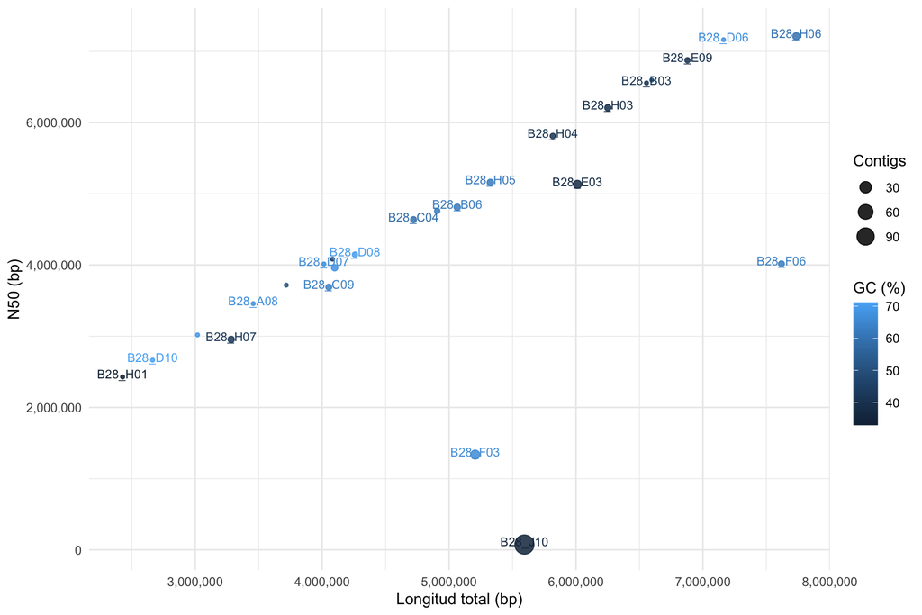

# Discriminación por k-mers

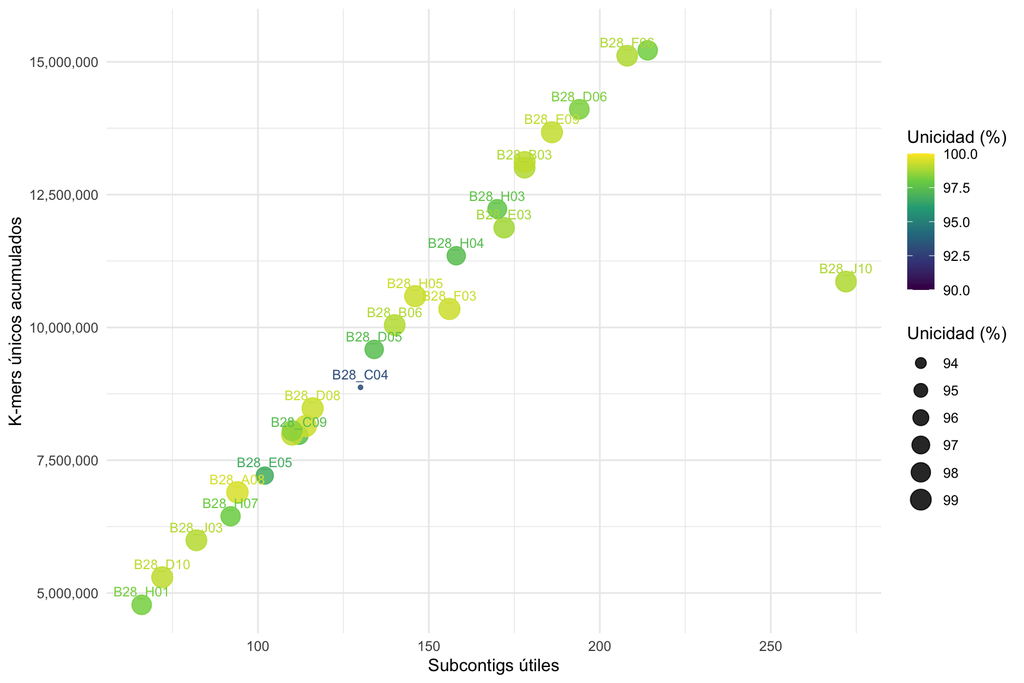

# Perfil normalizado por cepa

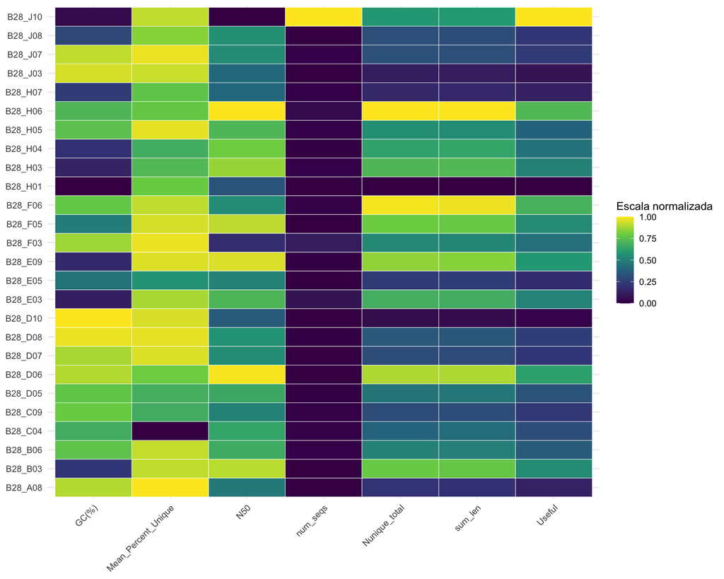

La Fase 1 corresponde a la preparación de `StrainR2DB`. La Fase 2, que compara lecturas FASTQ mediante `scripts/10_run_strainr.sh`, queda preparada pero no se ejecuta en este informe.

# Evaluación de la referencia

## Evidencia favorable

| Indicador | Resultado |
| --- | --- |
| Cepa con unicidad >=95% | 25 de 26 |
| Cepa con unicidad >=98% | 19 de 26 |
| Cepa con unicidad >=99% | 10 de 26 |
| Menor unicidad | 04_B28_C04 (93.11%) |
| Mayor unicidad | 01_B28_A08 (99.47%) |

La referencia presenta evidencia favorable para StrainR2: las 26 cepas tienen subcontigs útiles, 25 de 26 presentan al menos 95% de unicidad promedio y 19 de 26 al menos 98%. La menor unicidad corresponde a `B28_C04` (93,11%), mientras que la mayor corresponde a `B28_A08` (99,47%). En conjunto, la referencia parece adecuada para una primera cuantificación a nivel de cepa.

## Qué significa “diferenciar” aquí

`Percent_Unique` alto significa que muchos k-mers de los subcontigs no aparecen en los demás genomas del consorcio. Esto favorece la asignación de lecturas a una cepa. No significa que las cepas estén igualmente alejadas evolutivamente ni garantiza que todas puedan detectarse en una muestra de baja profundidad.

Para confirmar que cada par de cepas es distinguible se necesitaría una comparación pairwise de los genomas o de sus conjuntos de k-mers, por ejemplo ANI, Mash o una matriz de similitud. Esa información no está contenida en `KmerContent.report`, que guarda conteos y porcentajes por subcontig, no las identidades completas de todos los k-mers.

## Conclusión operacional

La base puede considerarse **apta como referencia inicial** porque tiene 3.706 subcontigs útiles y una unicidad promedio de 98,4020%. `B28_C04` debe interpretarse con mayor cautela por su menor unicidad. La validación definitiva será la Fase 2: una muestra simulada o controlada con las 26 cepas debería recuperar las cepas presentes y mantener bajas las señales de las ausentes.